# MHIA 6160: Value & Quality in Healthcare

- Show All Code
- Hide All Code
- View Source

Week 4 R-Laboratory: Modelling with DAEDALUS Explore

Author

Dr. Cameron B. Chiarot

## Laboratory Overview

Welcome to the Week 4 R-Laboratory. In Week 3, we mastered the ingestion and visualization of a single pandemic scenario, learning how to view a crisis through both a Health System Lens and an Industry Lens.

However, in executive health administration, you are rarely asked to analyze a single scenario; you are expected to weigh strategic options and recommend evidence-based interventions for stakeholders. To prepare for your Capstone, this lab transitions from descriptive visualization to **Comparative Scenario Analysis**.

Today, we will ingest a second dataset (representing an active policy intervention), merge it with our Week 3 baseline dataframe, and construct comparative visuals and boardroom-ready summary tables using the `gt` package.

Today’s session is divided into four progressive parts:

1. **Part I: Multi-Scenario Data Ingestion & Binding**
2. **Part II: Flattening the Curve (Comparative Health Lens)**
3. **Part III: The Economic Inverse (Comparative Industry Lens)**
4. **Part IV: The Executive Summary Table**

## Part I: Multi-Scenario Data Ingestion & Binding

To compare policies, we must first bring both datasets into the same R environment. We will use the `mutate()` function to “tag” each dataset with its respective scenario name, and then use `bind_rows()` to stack them into master dataframes for comparative plotting.

**Step 1: Data Acquisition**

Navigate to the [DAEDALUS Explore Web Dashboard](https://daedalus.jameel-institute.org/scenarios/new). You will need two `.xlsx` exports from DAEDALUS Explore in your `data` subfolder:

**Scenario 1 Parameters (Baseline)**

- **Country:** Canada
- **Pathogen:** SARS 2004
- **Closures:** None
- **Global vaccine investment:** Low
- **Change in public behaviour:** Low
- **Hospital surge capacity:** 8000

**Scenario 2 Parameters (Intervention)**

- **Country:** Canada
- **Pathogen:** SARS 2004
- **Closures:** Economic_closures
- **Global vaccine investment:** Low
- **Change in public behaviour:** Medium
- **Hospital surge capacity:** 8000

**Important**

After selecting the parameters, click the **Run** button to run the simulation. When the simulation is complete, click the **Export** button to download the resulting `.xlsx` workbook to your local computer.

**Step 2: Project Housekeeping & Parameter Audit**

Before merging, it is best practice to audit the `Parameters` tab of both files to ensure you downloaded the correct simulation data. First, we will load the appropriate R libraries and call in the two datasets then begin exploring the parameters.

```r
# Load necessary packages
library(tidyverse)
library(readxl)
library(here)
library(gt) # For Part IV

# Define the file paths dynamically
file_path_s1 <- here("data",
                     "daedalus_CAN_low_sars_cov_1_none_low_8000.xlsx")
file_path_s2 <- here("data",
                     "daedalus_CAN_low_sars_cov_1_economic_closures_medium_8000.xlsx")

# Audit the Parameters tab to verify the scenario inputs
scenario_1 <- read_excel(file_path_s1, sheet = "Parameters")
scenario_2 <- read_excel(file_path_s2, sheet = "Parameters")

glimpse(scenario_1$value)
glimpse(scenario_2$value)

# Scenario 1 Parameter List Output:
## chr [1:6] "CAN" "low" "sars_cov_1" "none" "low" "8000"

# Scenario 2 Parameter List Output:
## chr [1:6] "CAN" "low" "sars_cov_1" "economic_closures" "medium" "8000"
```

**Step 3: Comparative Preprocessing (Health Data)**

We will read the `Time series` tab for both scenarios, tag them, and bind them into a single `clean_health_comp` dataframe.

```r
################
# HEALTH DATA
################

# SCENARIO 1
# Process Health Data (BASELINE)
health_s1 <- read_excel(file_path_s1, sheet = "Time series") %>%
  select(day, new_hospitalised) %>%
  mutate(scenario_type = "Scenario 1: No Closures") # Creates a categorical tag

# SCENARIO 2
# Process Health Data (INTERVENTION)
health_s2 <- read_excel(file_path_s2, sheet = "Time series") %>%
  select(day, new_hospitalised) %>%
  mutate(scenario_type = "Scenario 2: Economic Closures")

# SCENARIO 1 + SCENARIO 2
# Bind rows together into a master dataframe
clean_health_comp <- bind_rows(health_s1, health_s2)

# AUDIT THE COMBINED STRUCTURE
glimpse(clean_health_comp)
```

**Step 4: Comparative Preprocessing (Economic Data)**

We repeat the exact same tagging and binding process for the macroeconomic `Costs` tab.

```r
################
# ECONOMIC DATA
################

# SCENARIO 1
# Process Economic Data (BASELINE)
econ_s1 <- read_excel(file_path_s1, sheet = "Costs") %>%
  filter(costId %in% c("gdp_closures", "gdp_absences", "education")) %>%
  mutate(
    value_billions = value / 1000,
    costId = case_when(
      costId == "gdp_closures" ~ "GDP Loss: Business Closures",
      costId == "gdp_absences" ~ "GDP Loss: Worker Absenteeism",
      costId == "education" ~ "Future Human Capital (Education)"
    ),
    scenario_type = "Scenario 1: No Closures" # Tag
  )

# SCENARIO 2
# Process Economic Data (INTERVENTION)
econ_s2 <- read_excel(file_path_s2, sheet = "Costs") %>%
  filter(costId %in% c("gdp_closures", "gdp_absences", "education")) %>%
  mutate(
    value_billions = value / 1000,
    costId = case_when(
      costId == "gdp_closures" ~ "GDP Loss: Business Closures",
      costId == "gdp_absences" ~ "GDP Loss: Worker Absenteeism",
      costId == "education" ~ "Future Human Capital (Education)"
    ),
    scenario_type = "Scenario 2: Economic Closures" # Tag
  )

# SCENARIO 1 + SCENARIO 2
# Bind rows together into a master dataframe
clean_econ_comp <- bind_rows(econ_s1, econ_s2)

# AUDIT THE COMIBINED STRUCTURE
glimpse(clean_econ_comp)
```

## Part II: Flattening the Curve (Comparative Health Lens)

Because we stacked our data and tagged it with a `scenario_type` column in Part I, we can map this new variable directly to the `color` and `linetype` aesthetics in `ggplot2`.

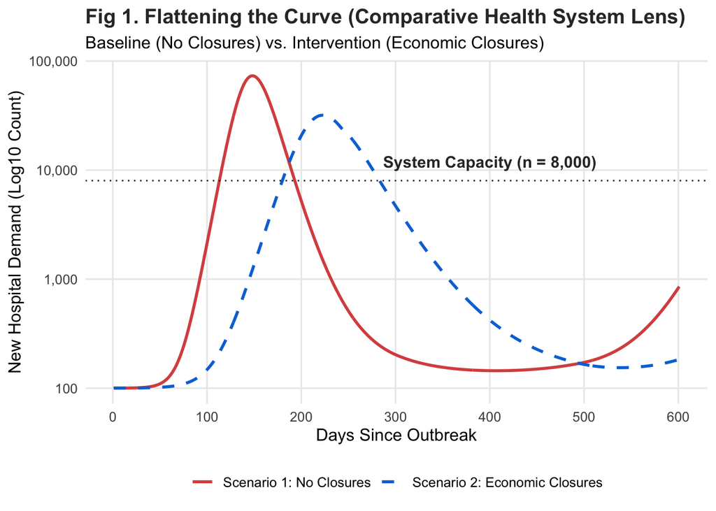

```r
# Establish the clinical capacity constraint
hospital_capacity <- 8000

# Build the Comparative Epidemiological Time-Series
health_plot <- ggplot(data = clean_health_comp, aes(x = day, y = new_hospitalised + 100,
                                                    color = scenario_type,
                                                    linetype = scenario_type)) +

  # Map the time-series curves
  geom_line(linewidth = 1) +

  # Add the Clinical Ceiling Intercept
  geom_hline(yintercept = hospital_capacity, linetype = "dotted",
             color = "#333333", linewidth = 0.5) +

  # Annotate the breach
  annotate("text", x = 400, y = 12000, label = "System Capacity (n = 8,000)",
           color = "#333333", fontface = "bold", size = 4) +

  # Explicit Axis Scaling
  scale_y_log10(labels = scales::comma_format()) +
  scale_x_continuous(breaks = seq(0, 600, by = 100)) +

  # Define executive colors and line styles
  scale_color_manual(values = c("Scenario 1: No Closures" = "#d9534f",
                                "Scenario 2: Economic Closures" = "#0275d8")) +
  scale_linetype_manual(values = c("Scenario 1: No Closures" = "solid",
                                   "Scenario 2: Economic Closures" = "dashed")) +

  # Executive Formatting
  labs(
    title = "Fig 1. Flattening the Curve (Comparative Health System Lens)",
    subtitle = "Baseline (No Closures) vs. Intervention (Economic Closures)",
    x = "Days Since Outbreak",
    y = "New Hospital Demand (Log10 Count)",
    color = "Policy Scenario",             # Titles the legend
    linetype = "Policy Scenario"           # Merges linetype and color into one legend
  ) +

  theme_minimal(base_size = 12) +
  theme(
    plot.title = element_text(face = "bold", color = "#333333"),
    panel.grid.minor = element_blank(),
    legend.position = "bottom",       # Moves legend to the bottom for boardroom visuals
    legend.title = (element_blank())  # Removes legend title
  )
health_plot
```

**NoteR-Visualization Note: Mapping vs. Hardcoding**

In Week 3, we *hardcoded* our line color by placing it outside the `aes()` function (e.g., `geom_line(color = "red")`). In this comparative plot, we *mapped* our line color to a variable by placing it inside the `aes()` function (e.g., `aes(color = scenario_type)`). This instructs R to look inside the dataframe, identify the distinct categories, and assign a unique visual property to each one. We then used `scale_color_manual()` to dictate exactly which colors to use for maximum contrast.

**ImportantExecutive Interpretation**

## Part III: The Economic Inverse (Comparative Industry Lens)

Lockdowns and economic closures may flatten the clinical curve, but that policy choice carries a severe macroeconomic price tag. To visualize the exact trade-off, we will plot our macroeconomic indicators side-by-side.

Because we stacked our data in Part I, we can map the `scenario_type` variable to the `fill` aesthetic and use a dodging geometry to compare the financial damage of doing nothing (Baseline) versus shutting down the economy (Intervention).

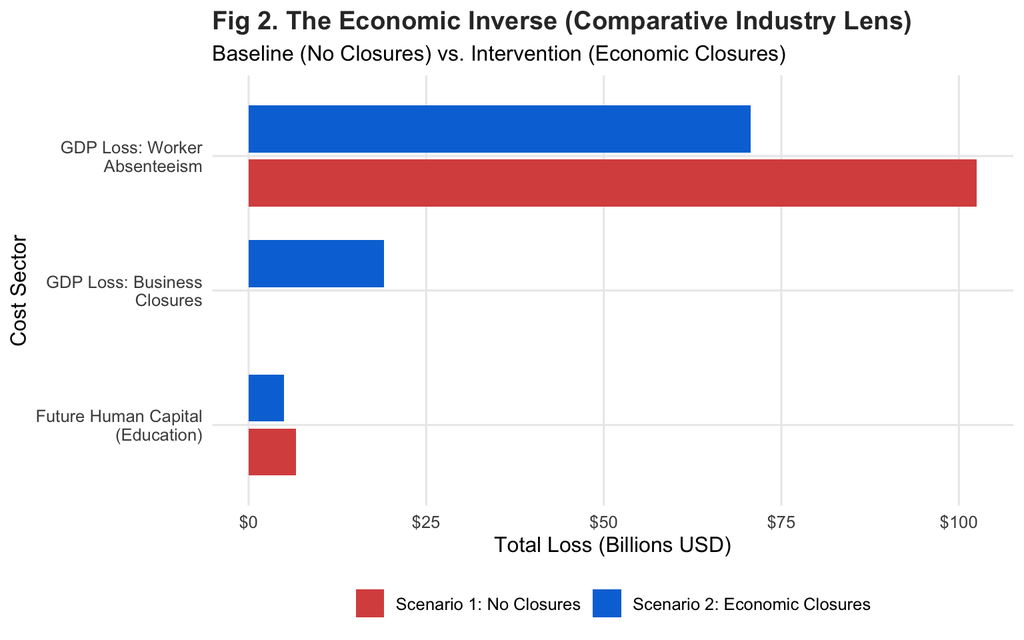

```r
# Build the Comparative Macroeconomic Bar Chart
econ_plot <- ggplot(data = clean_econ_comp, aes(x = reorder(costId, value_billions),
                                                y = value_billions,
                                                fill = scenario_type)) +

  # Map the categorical bars, set position to dodge for side-by-side comparison
  geom_col(position = position_dodge(width = 0.8), width = 0.7, alpha = 1) +

  # Flip coordinates for readable executive labels
  coord_flip() +

  # Explicit Axis Scaling
  scale_y_continuous(labels = scales::dollar_format(prefix = "$")) +
  scale_x_discrete(labels = function(x) stringr::str_wrap(x, width = 20)) +

  # 4. Define executive colors to match the Health Lens
  scale_fill_manual(values = c("Scenario 1: No Closures" = "#d9534f",
                               "Scenario 2: Economic Closures" = "#0275d8")) +

  # Executive Formatting
  labs(
    title = "Fig 2. The Economic Inverse (Comparative Industry Lens)",
    subtitle = "Baseline (No Closures) vs. Intervention (Economic Closures)",
    x = "Cost Sector",
    y = "Total Loss (Billions USD)",
    fill = "Policy Scenario"
  ) +

  theme_minimal(base_size = 12) +
  theme(
    plot.title = element_text(face = "bold", color = "#333333"),
    panel.grid.minor = element_blank(),
    legend.title = (element_blank()),  # Removes legend title
    legend.position = "bottom"
  )
econ_plot
```

**NoteR-Visualization Note: The Power of Position Dodge**

By default, if you map a categorical variable to the `fill` aesthetic in a bar chart, `ggplot2` will stack the bars on top of each other (`position = "stack"`). While stacked bars are useful for showing parts of a whole, they make it difficult to compare precise baseline and intervention values.

By adding `position = position_dodge()` inside the `geom_col()` function, we force the software to render the bars side-by-side. This is the optimal configuration for comparative executive analysis.

**ImportantExecutive Interpretation**

This visualization illustrates the core dilemma of health administration. Notice how the blue intervention bar for **GDP Loss: Worker Absenteeism** shrinks compared to the baseline (because fewer people are sick), but the blue bar for **GDP Loss: Business Closures** spikes massively.

The intervention did not eliminate the economic damage; it merely *transferred* the damage from unmitigated biological spread to state-mandated closures. Your Capstone task is to find a policy balance that minimizes both.

## Part IV: The Capstone Synthesis (Figure & Table)

When presenting to stakeholders, executives expect a concise, unified summary. Your Capstone deliverable will require two distinct formats: a **Master Figure** (ideal for your Summit Pitch slide deck) and an **Executive Summary Table** (essential for your Written Brief).

**The Master Figure (Dashboard)**

We will use the `patchwork` package to stitch our Comparative Health Lens (Part II) and Comparative Industry Lens (Part III) together into a single, unified dashboard.

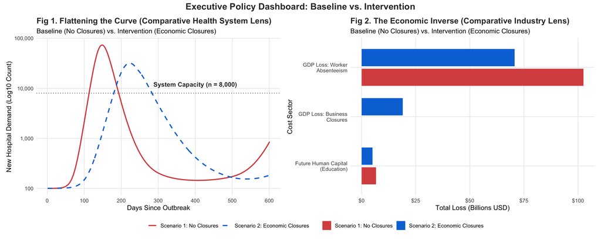

```r
library(patchwork)

# Assuming you assigned your Part II plot to 'health_plot' and Part III to 'econ_plot'

# We stitch the Part II and Part III plots; we will pull them together and collect the legends so they share one unified key at the bottom.

exec_dashboard <- health_plot + econ_plot +
  plot_layout(guides = "collect") +
  plot_annotation(
    title = "Executive Policy Dashboard: Baseline vs. Intervention",
    theme = theme(plot.title = element_text(face = "bold", size = 16, hjust = 0.5, color = "#333333"))
  ) &
  theme(legend.position = "bottom") # The & operator must go at the very end

exec_dashboard
```

**The Executive Summary Table**

Visuals are excellent for communicating trends, but decision-makers also need the hard bottom-line numbers. We will use the `group_by()` and `summarize()` functions to calculate the peak hospital demand and the total economic loss for both scenarios, and then use the `gt` (Grammar of Tables) package to format these numbers into a boardroom-ready table.

```r
# Step A: Calculate the peak hospital demand per scenario
health_summary <- clean_health_comp %>%
  group_by(scenario_type) %>%
  summarize(peak_hospital_demand = max(new_hospitalised))

# Step B: Calculate the total macroeconomic loss per scenario
econ_summary <- clean_econ_comp %>%
  group_by(scenario_type) %>%
  summarize(total_economic_loss_billions = sum(value_billions))

# Step C: Join the two summaries together
exec_summary_df <- health_summary %>%
  left_join(econ_summary, by = "scenario_type")

# Step D: Format the dataframe into a polished table using gt()
exec_summary_df %>%
  gt() %>%

  # Add titles and subtitles
  tab_header(
    title = md("**Executive Policy Summary**"),
    subtitle = "Peak Clinical Demand vs. Total Macroeconomic Contraction"
  ) %>%

  # Format numbers (Commas for beds, Currency for dollars)
  fmt_number(
    columns = peak_hospital_demand,
    decimals = 0,
    use_seps = TRUE
  ) %>%
  fmt_currency(
    columns = total_economic_loss_billions,
    currency = "USD",
    decimals = 2,
    pattern = "{x} B"
  ) %>%

  # Rename columns for executive presentation
  cols_label(
    scenario_type = "Policy Scenario",
    peak_hospital_demand = "Peak Hospital Demand (Beds)",
    total_economic_loss_billions = "Total Economic Loss"
  ) %>%

  # Add a professional source note
  tab_source_note(
    source_note = "Data generated via DAEDALUS Explore Simulation (SARS 2004, Canada)."
  ) %>%

  # Apply a clean, classic theme
  opt_table_font(font = "Arial") %>%
  tab_options(
    table.border.top.color = "#333333",
    table.border.bottom.color = "#333333",
    heading.background.color = "#f8f9fa"
  )
```

**Executive Policy Summary**

Peak Clinical Demand vs. Total Macroeconomic Contraction

| Policy Scenario | Peak Hospital Demand (Beds) | Total Economic Loss |
| --- | --- | --- |
| Scenario 1: No Closures | 73,171 | $109.19 B |
| Scenario 2: Economic Closures | 31,770 | $94.72 B |

Data generated via DAEDALUS Explore Simulation (SARS 2004, Canada).

# Week 4 R-Laboratory Synthesis Deliverable

Using the master dashboard and the summary table generated in Part IV, write a 1-paragraph (~200 words) brief to the Minister of Health. State whether you recommend adopting Scenario 2 (Economic Closures) over Scenario I (Baseline, No Closures), and justify your recommendation using at least one specific clinical data point and one macroeconomic data point from your analysis.

**{end}**